# EDA

Janice Cessna

November 30, 2019

# Basic data review

Five number summary of select variables:

```r
summary(flights_2018[c(1, 10:18, 24:29, 31:44)])
```

```
##       Date              Dep_Delay           Taxi_Out
##  Min.   :2018-01-01   Min.   : -39.000   Min.   :  0.00
##  1st Qu.:2018-03-31   1st Qu.:  -5.000   1st Qu.: 11.00
##  Median :2018-06-30   Median :  -2.000   Median : 15.00
##  Mean   :2018-07-01   Mean   :   9.804   Mean   : 17.11
##  3rd Qu.:2018-09-30   3rd Qu.:   6.000   3rd Qu.: 20.00
##  Max.   :2018-12-31   Max.   :1410.000   Max.   :180.00
##
##     Taxi_In          Arr_Delay        Cancelled
##  Min.   :  0.000   Min.   : -82.000   No :118046
##  1st Qu.:  4.000   1st Qu.: -14.000   Yes:  1954
##  Median :  6.000   Median :  -5.000
##  Mean   :  7.478   Mean   :   4.949
##  3rd Qu.:  9.000   3rd Qu.:   7.000
##  Max.   :152.000   Max.   :1498.000
##
##            Cancellation_Code  Diverted
##  Carrier            :   470   No :119729
##  Security           :     2   Yes:   271
##  Weather            :  1041
##  National Air System:   441
##  NA's               :118046
##
##
##     Air_Time                                  Distance
##  Min.   :420s (~7 minutes)                 Min.   :  31.0
##  1st Qu.:3600s (~1 hours)                  1st Qu.: 363.0
##  Median :5580s (~1.55 hours)               Median : 639.0
##  Mean   :6705.15066864785s (~1.86 hours)   Mean   : 801.8
##  3rd Qu.:8460s (~2.35 hours)               3rd Qu.:1034.0
##  Max.   :39480s (~10.97 hours)             Max.   :4983.0
##  NA's   :2225
##  Dep_Time_Planned_UTC          Dep_Time_Actual_UTC
##  Min.   :2018-01-01 06:30:00   Min.   :2018-01-01 06:22:00
##  1st Qu.:2018-04-01 07:05:00   1st Qu.:2018-04-01 21:49:30
##  Median :2018-07-01 07:32:30   Median :2018-07-01 20:37:30
##  Mean   :2018-07-02 01:19:14   Mean   :2018-07-02 13:48:21
##  3rd Qu.:2018-10-01 07:14:00   3rd Qu.:2018-10-01 19:10:00
##  Max.   :2019-01-01 07:59:00   Max.   :2019-01-01 07:51:00
##                                NA's   :1980
```

[output cut: 49 more lines]

```
##  Min.   : 0.00              Min.   : 0.00
##  1st Qu.:15.00              1st Qu.:10.00
##  Median :30.00              Median :15.00
##  Mean   :29.33              Mean   :14.38
##  3rd Qu.:45.00              3rd Qu.:19.00
##  Max.   :59.00              Max.   :24.00
##                             NA's   :1994
##  Arr_Time_Planned_Actual_Min
##  Min.   : 0.00
##  1st Qu.:15.00
##  Median :29.00
##  Mean   :29.48
##  3rd Qu.:44.00
##  Max.   :59.00
##  NA's   :1994
```

Review of summaries does not immediately reveal any anomalies. Spot check of some potentially unusual variables (e.g. 420 second Air_Time and 31 minimum Distance) all checked out as seemingly legitimate.

Total NA’s in all variables:

```r
flights_2018 %>% summarize_all(funs(sum(is.na(.))))
```

```
## # A tibble: 1 x 47
##    Date Carrier_Code Tail_Num Origin Origin_City Origin_State  Dest
##   <int>        <int>    <int>  <int>       <int>        <int> <int>
## 1     0            0      267      0           0            0     0
## # ... with 40 more variables: Dest_City <int>, Dest_State <int>,
## #   Dep_Delay <int>, Taxi_Out <int>, Taxi_In <int>, Arr_Delay <int>,
## #   Cancelled <int>, Cancellation_Code <int>, Diverted <int>,
## #   Air_Time <int>, Distance <int>, Carrier_Delay <int>,
## #   Weather_Delay <int>, Nas_Delay <int>, Security_Delay <int>,
## #   Late_Ac_Delay <int>, Dep_Time_Planned_UTC <int>,
## #   Dep_Time_Actual_UTC <int>, Wheels_Off_UTC <int>, Wheels_On_UTC <int>,
## #   Arr_Time_Actual_UTC <int>, Arr_Time_Planned_UTC <int>,
## #   Carrier_Name <int>, Tot_Ops.x <int>, Tot_Ops.y <int>,
## #   Dep_Time_Planned_Local_Hour <int>, Dep_Time_Planned_Local_Min <int>,
## #   Dep_Time_Planned_Actual_Hour <int>, Dep_Time_Planned_Actual_Min <int>,
## #   Wheels_Off_Hour <int>, Wheels_Off_Min <int>, Wheels_On_Hour <int>,
## #   Wheels_On_Min <int>, Arr_Time_Planned_Local_Hour <int>,
## #   Arr_Time_Planned_Local_Min <int>, Arr_Time_Planned_Actual_Hour <int>,
## #   Arr_Time_Planned_Actual_Min <int>, Date_Month <int>, Date_Day <int>,
## #   Date_Weekday <int>
```

# Sub-variable creation

This section creates a handfull of new variables for deeper EDA analysis.

```r
#adds month, day of month, and weekday for each observation
flights_2018 <- flights_2018 %>%
  mutate(Date_Month = month(Date)) %>%
  mutate(Date_Day = mday(Date)) %>%
  mutate(Date_Weekday = wday(Date, label = TRUE))
```

```r
#converts air time to integer for analysis
flights_2018 <- flights_2018 %>%
  mutate(Air_Time = as.double(Air_Time) / 60)
```

```r
flights_cancel <- flights_2018 %>%
  filter(Cancelled == "Yes")
flights_divert <- flights_2018 %>%
  filter(Diverted == "Yes")
```

```r
saveRDS(flights_2018, file = "../data/flights_2018.Rds")
```

# Plot series: distribution of flights by different time periods

Date of flight: Full distribution

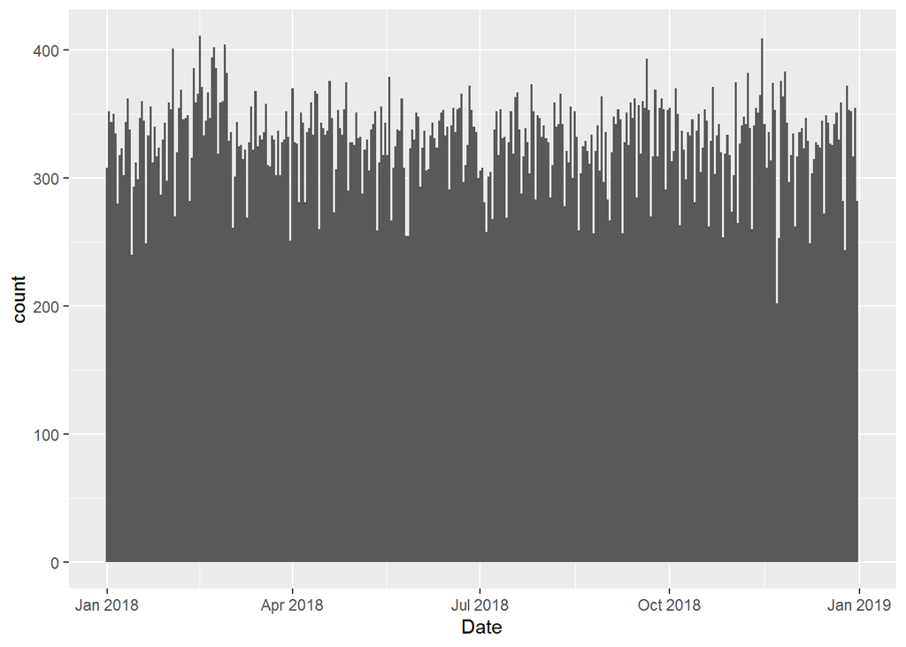

```r
flights_2018 %>%
  ggplot(aes(x = Date)) +
  geom_bar(binwidth = 1)
```

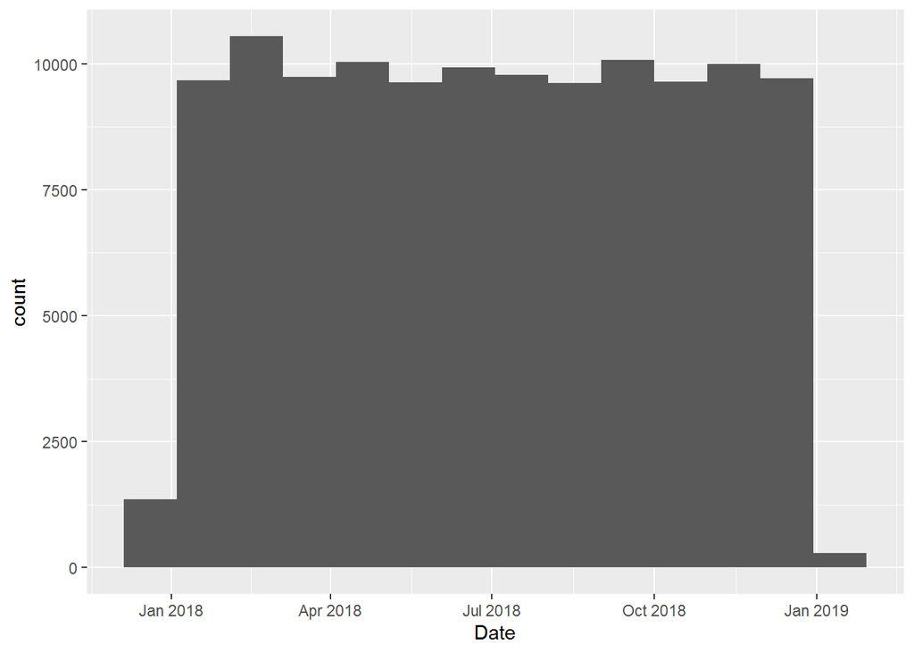

```r
flights_2018 %>%
  ggplot(aes(x = Date)) +
  geom_bar(binwidth = 30)
```

```r
par(mfrow = c(1,2))
```

```r
#total flights per day
flights_per_day <- flights_2018 %>%
  group_by(Date) %>%
  count()
summary(flights_per_day)
```

```
##       Date                  n
##  Min.   :2018-01-01   Min.   :202.0
##  1st Qu.:2018-04-02   1st Qu.:312.0
##  Median :2018-07-02   Median :333.0
##  Mean   :2018-07-02   Mean   :328.8
##  3rd Qu.:2018-10-01   3rd Qu.:351.0
##  Max.   :2018-12-31   Max.   :411.0
```

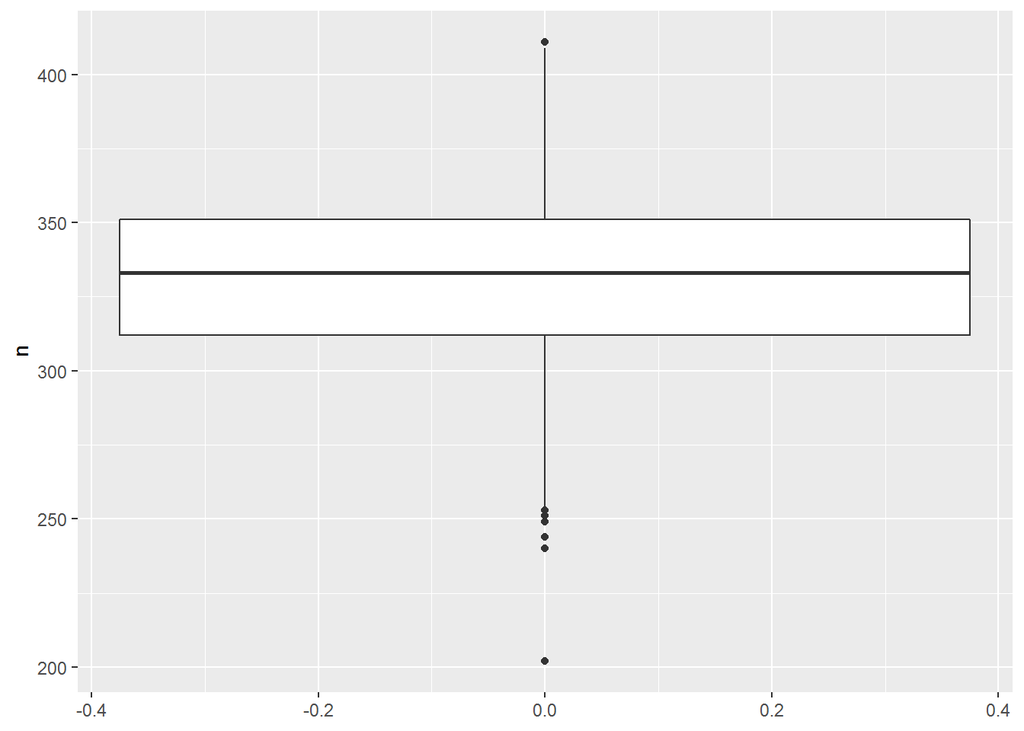

```r
flights_per_day %>%
  ggplot(aes(y = n)) +
  geom_boxplot()
```

```r
#which day has the most flights
flights_per_day_max <- which(flights_per_day$n == max(flights_per_day$n))
#which day has the fewest flights
flights_per_day_min <- which(flights_per_day$n == min(flights_per_day$n))
```

The most flights on a single day occured on 2018-02-15 which doesn’t appear to coincide with any major holiday or event. However, the fewest flights occured on 2018-11-22, which happens to be U.S. Thanksgiving. These dates, along with a few other minimum date counts appear as outliers on the boxplot, but a sample of 365 days suggests their influence is probably minimal.

```r
#clear min-max variables from global environment
rm(flights_per_day, flights_per_day_max, flights_per_day_min)
```

Number of flights per different time units

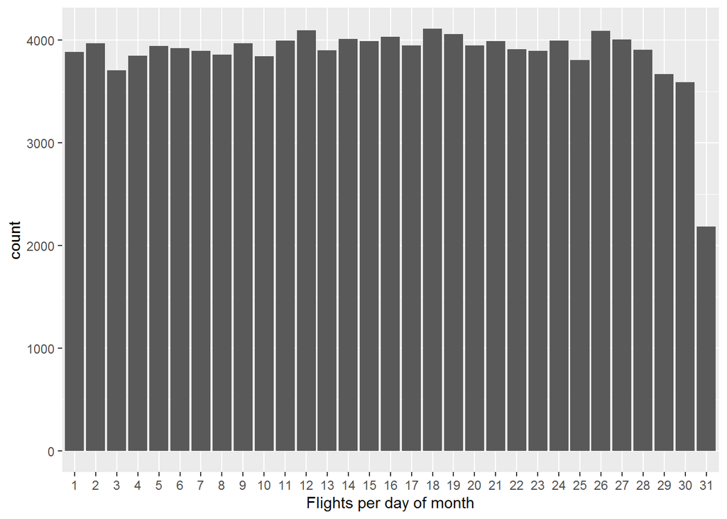

```r
flights_2018 %>%
  ggplot(aes(x = as.factor(Date_Day))) +
  geom_bar() +
  xlab("Flights per day of month")
```

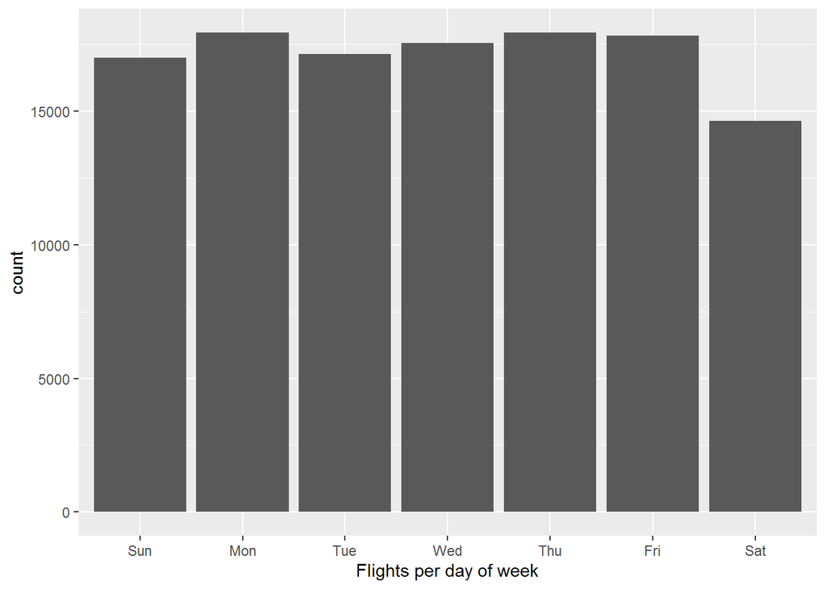

```r
flights_2018 %>%
  ggplot(aes(x = as.factor(Date_Weekday))) +
  geom_bar() +
  xlab("Flights per day of week")
```

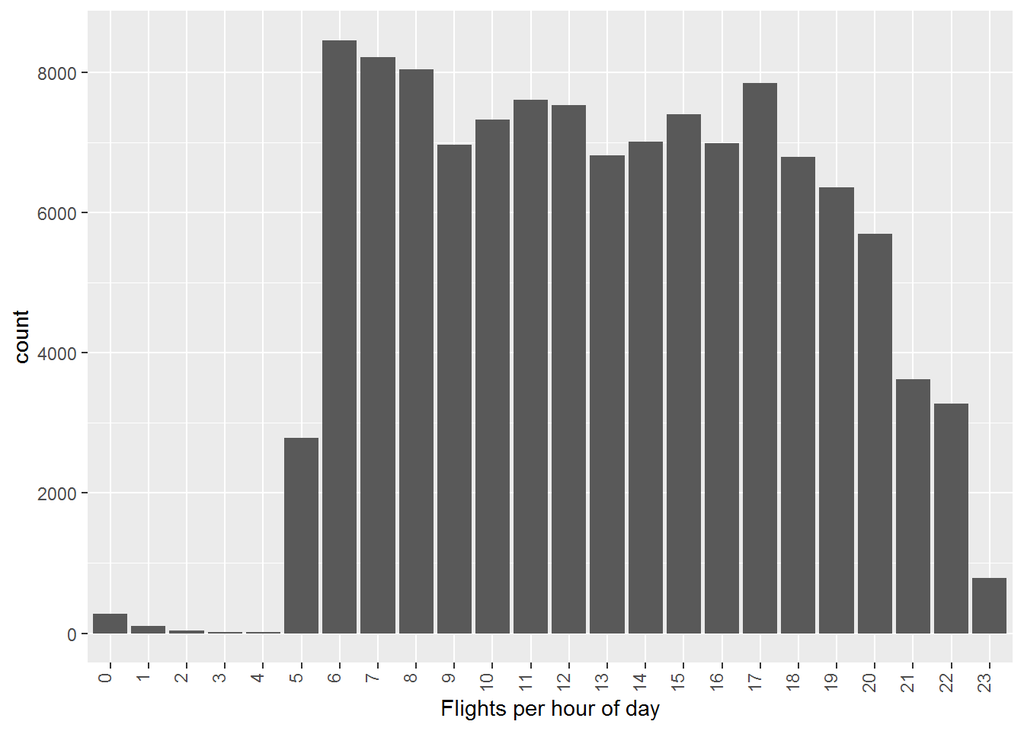

```r
flights_2018 %>%
  ggplot(aes(x = as.factor(Dep_Time_Planned_Local_Hour))) +
  geom_bar(stat = "count") +
  xlab("Flights per hour of day") +
  theme(axis.text.x = element_text(angle = 90, hjust = 1, vjust = 0))
```

```r
par(mfrow = c(2,2))
```

Number of flights per month not shown because that was the basis of data sampling. Thus, every month contains 10,000 flights.

# Plot series: misc variable distributions

Departure Delay: full distribution

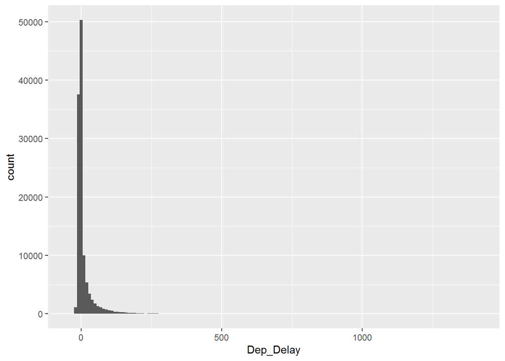

Not surprisingly, most delays are less than 60 minutes. However, the scale of this quantity makes it hard to see what is happening in the other x-axis areas. Below is a series looking closer at these.

Departure Delay: partial distributions

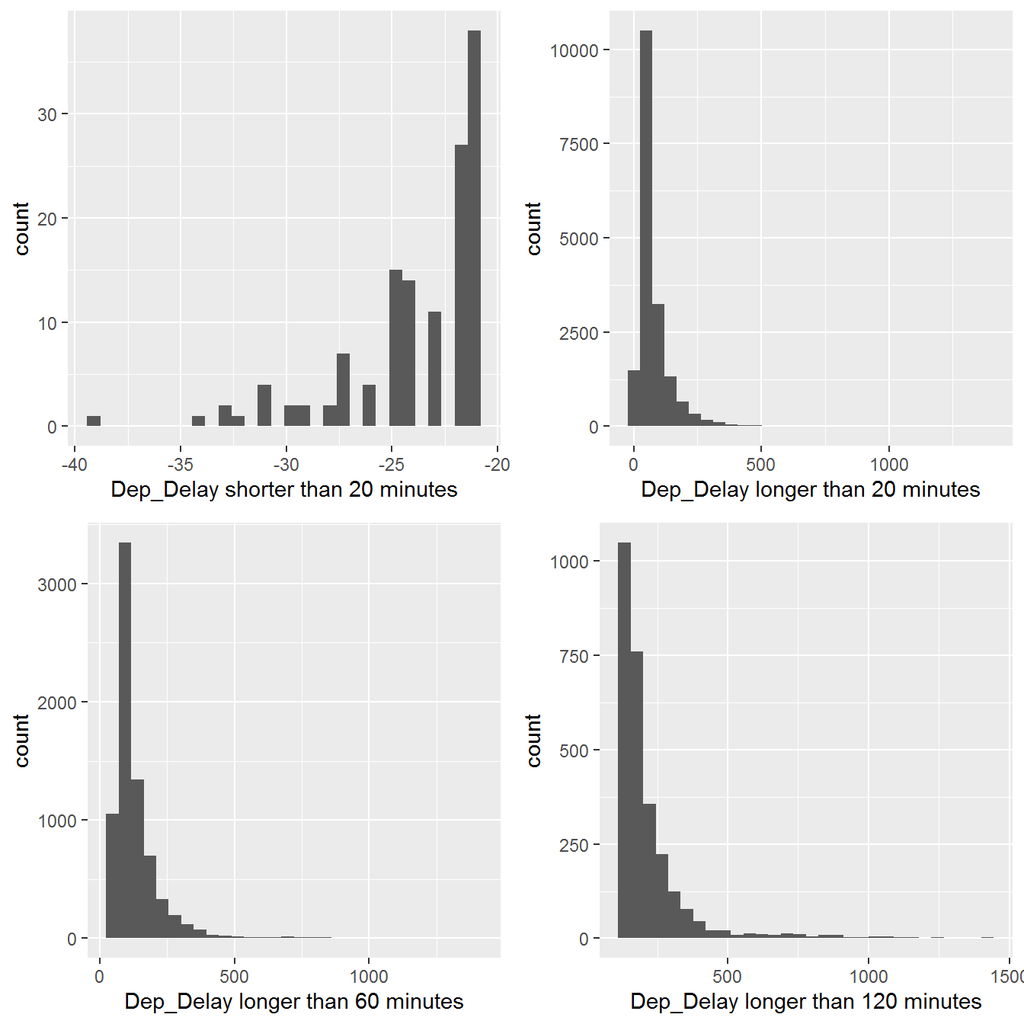

Arrival Delay: full distribution

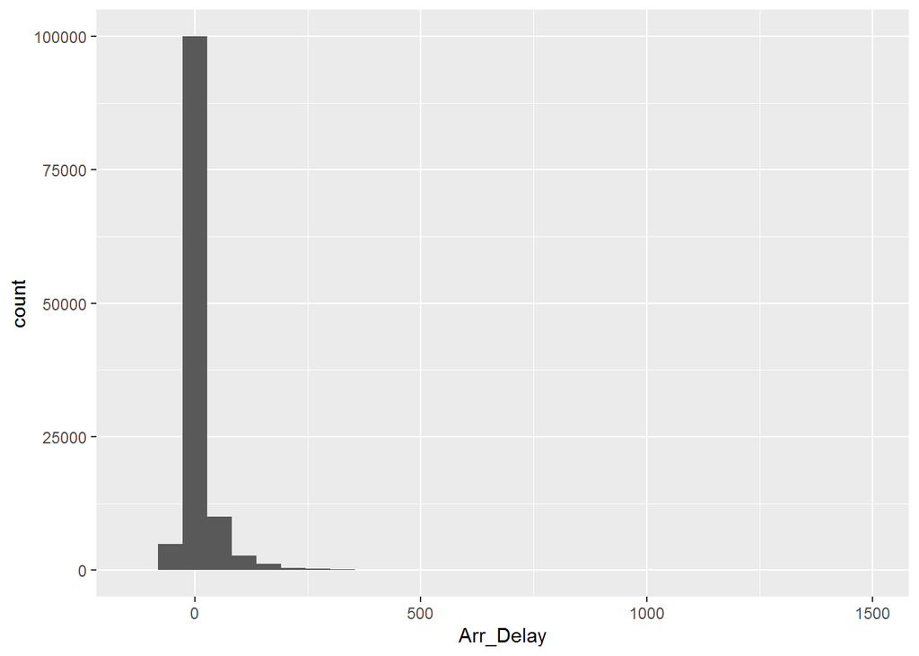

Like departure delays, most arrival delays are not surprisingly less than 60 minutes and the scale of this quantity makes it hard to see other x-axis areas. Below is a series looking closer at these.

Arrival Delay: Partial distributions

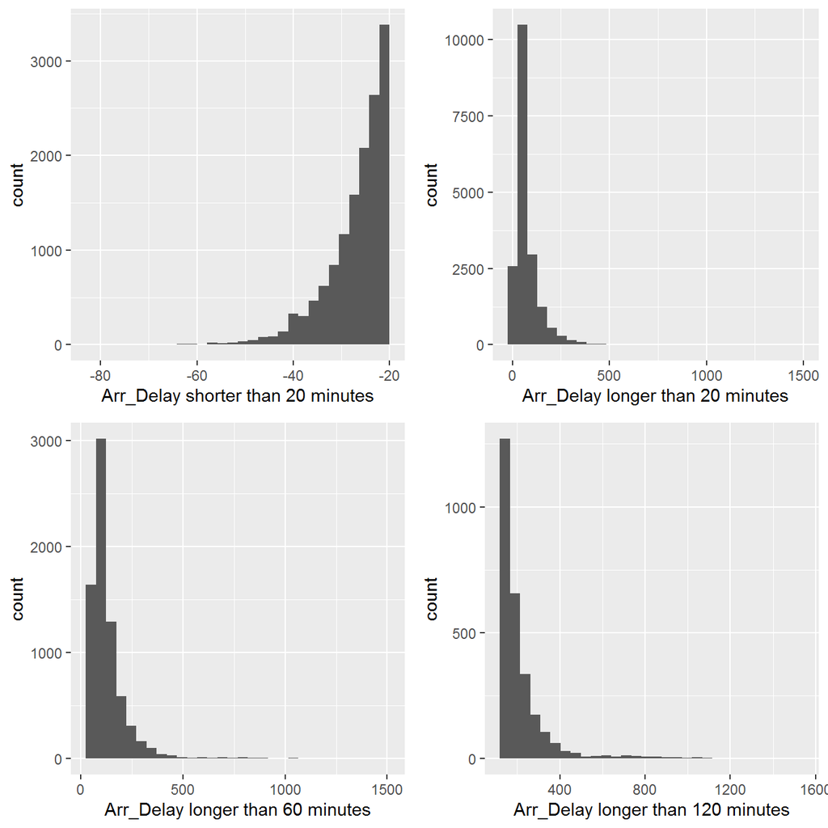

Taxi-out: full distribution

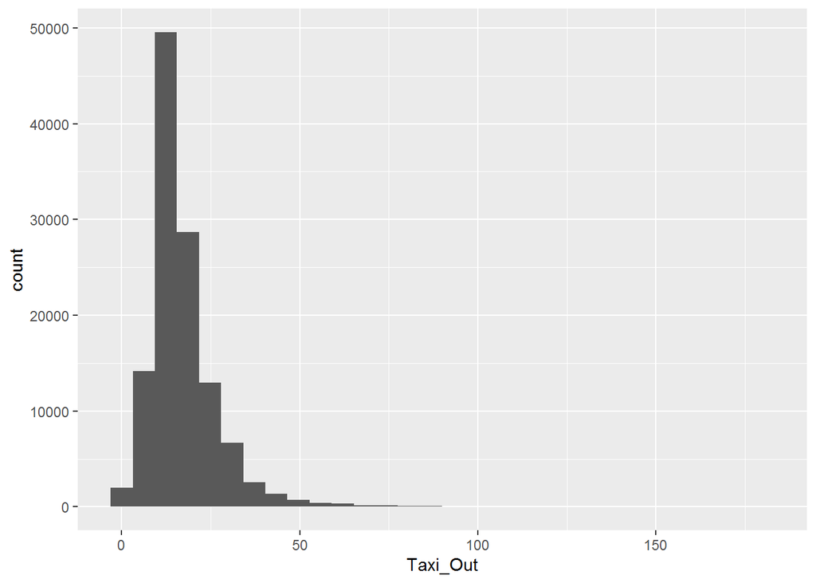

Taxi-In: full distribution

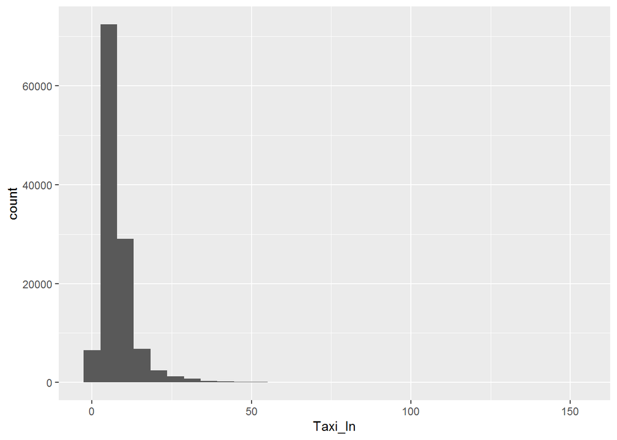

Cancellation Code categories:

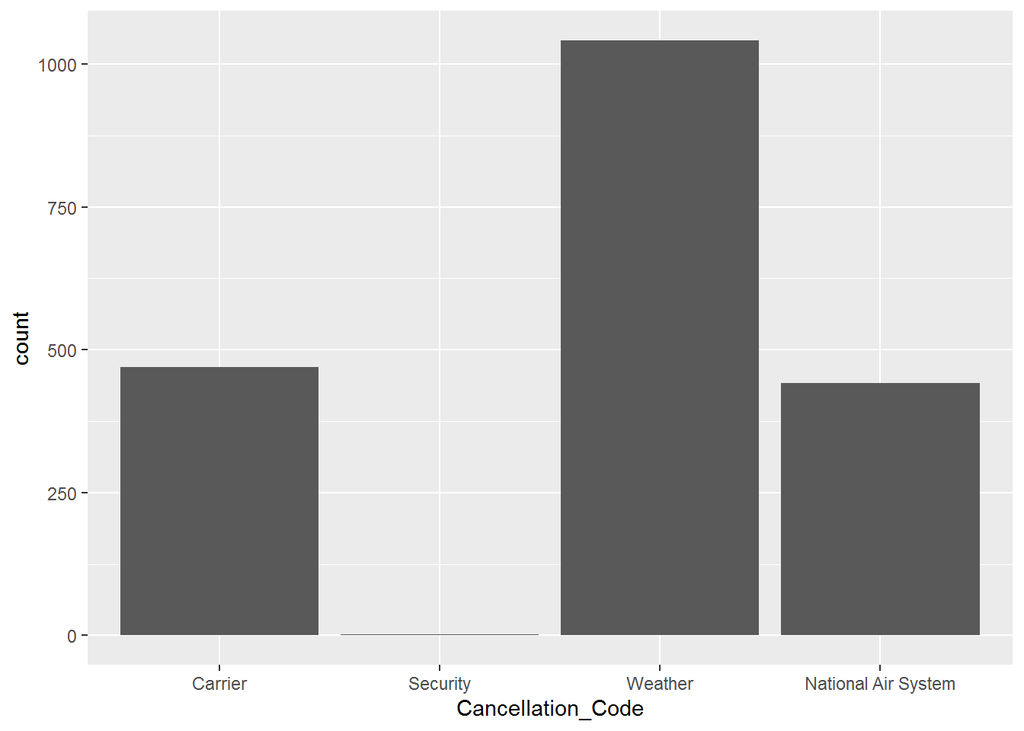

```r
flights_2018 %>%
  filter(!is.na(Cancellation_Code)) %>%
  ggplot(aes(x = Cancellation_Code)) +
  geom_bar()
```

# Plot series: variables by time periods

Departure delay vs explanatories

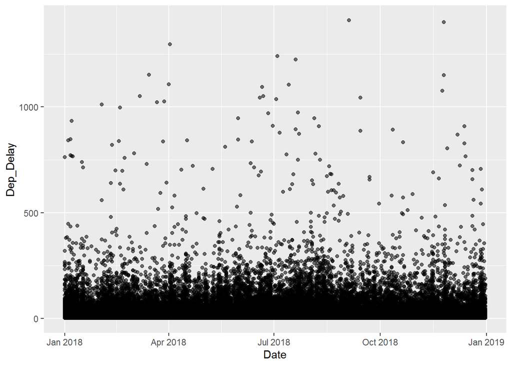

```r
flights_2018 %>%
  filter(Dep_Delay > 0) %>%
  ggplot(aes(x = Date, y = Dep_Delay, alpha = 0.1)) +
  geom_point() +
  theme(legend.position = "none")
```

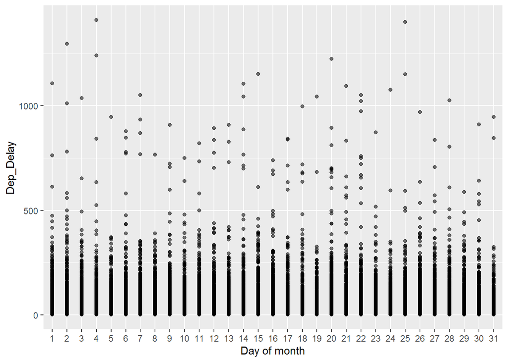

```r
flights_2018 %>%
  filter(Dep_Delay > 0) %>%
  ggplot(aes(x = as.factor(Date_Day), y = Dep_Delay, alpha = 0.1)) +
  geom_point() +
  xlab("Day of month") +
  theme(legend.position = "none")
```

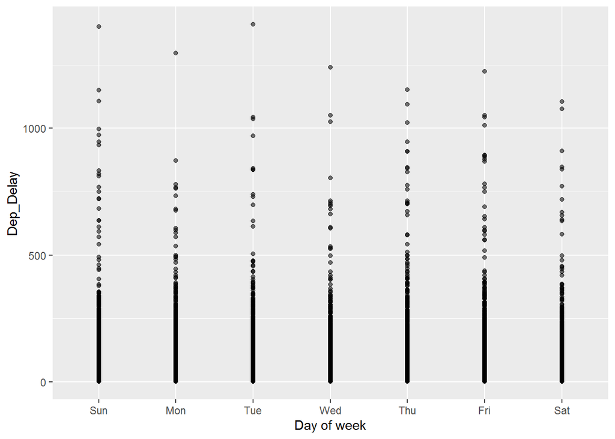

```r
flights_2018 %>%
  filter(Dep_Delay > 0) %>%
  ggplot(aes(x = as.factor(Date_Weekday), y = Dep_Delay, alpha = 0.1)) +
  geom_point() +
  xlab("Day of week") +
  theme(legend.position = "none")
```

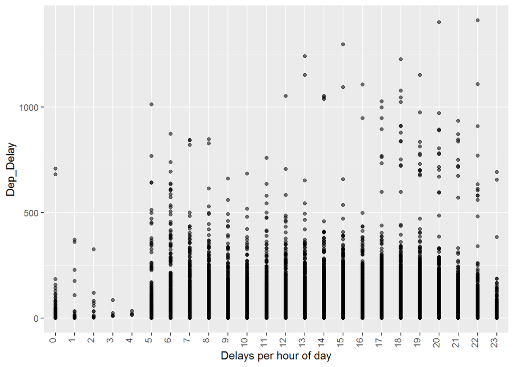

```r
flights_2018 %>%
  filter(Dep_Delay > 0) %>%
  ggplot(aes(x = as.factor(Dep_Time_Planned_Local_Hour),
             y = Dep_Delay, alpha = 0.1)) +
  geom_point() +
  xlab("Delays per hour of day") +
  theme(axis.text.x = element_text(angle = 90, hjust = 1, vjust = 0)) +
  theme(legend.position = "none")
```

```r
par(mfrow = c(2,2))
```

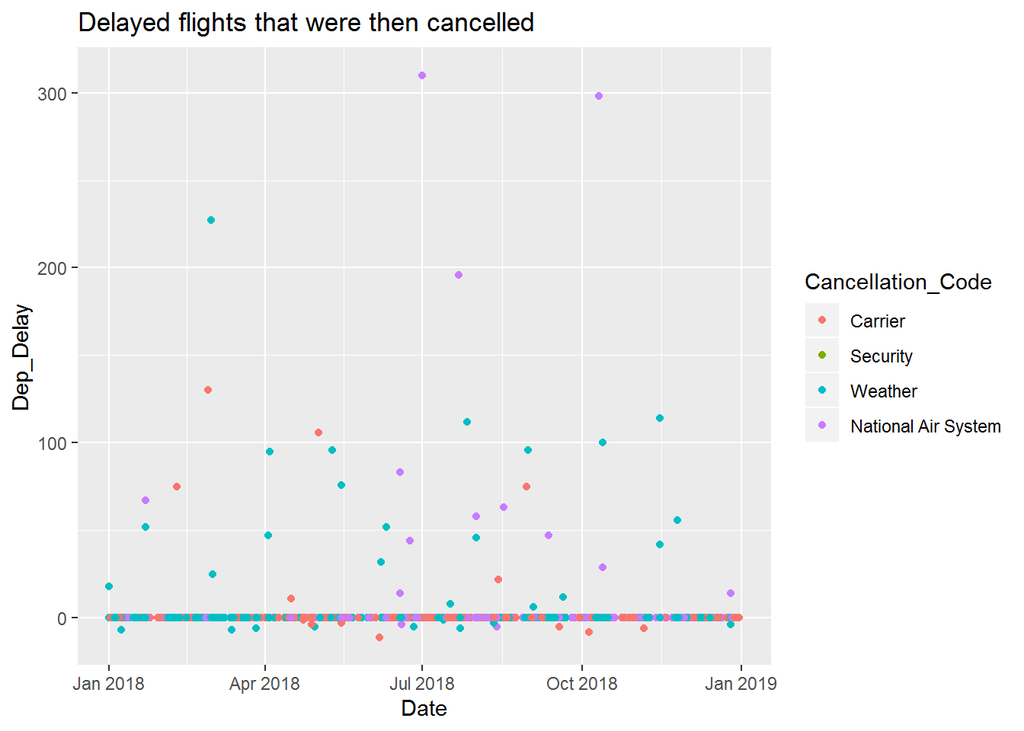

```r
flights_2018 %>%
  filter(Cancelled == "Yes") %>%
  ggplot(aes(x = Date, y = Dep_Delay, color = Cancellation_Code)) +
  geom_point() +
  labs(title = "Delayed flights that were then cancelled")
```

Arrival delay vs explanatories

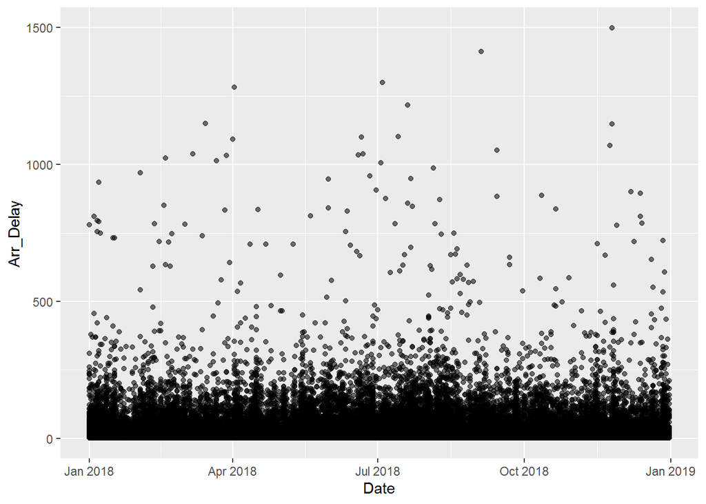

```r
flights_2018 %>%
  filter(Arr_Delay > 0) %>%
  ggplot(aes(x = Date, y = Arr_Delay, alpha = 0.1)) +
  geom_point() +
  theme(legend.position = "none")
```

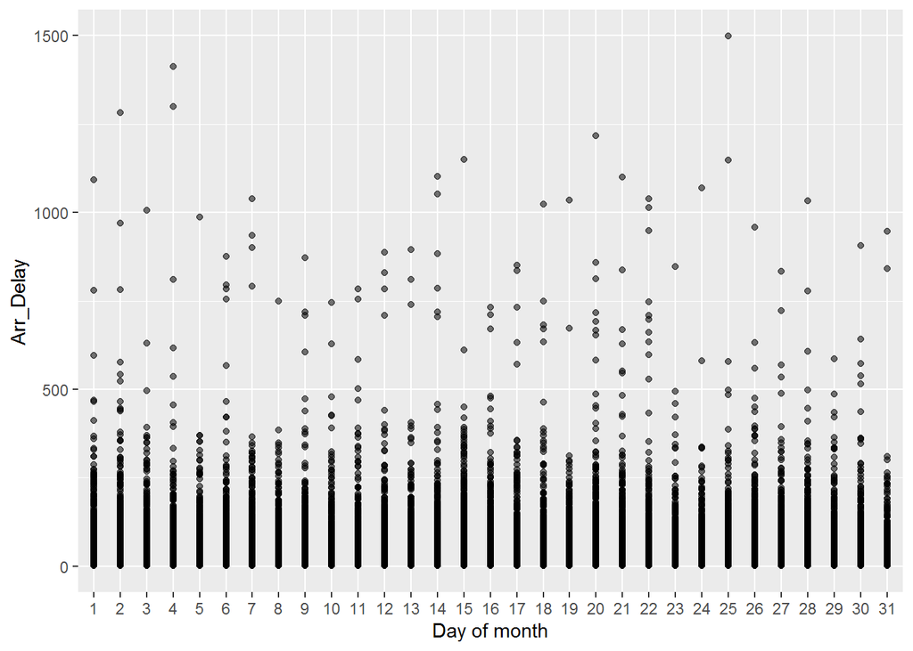

```r
flights_2018 %>%
  filter(Arr_Delay > 0) %>%
  ggplot(aes(x = as.factor(Date_Day), y = Arr_Delay, alpha = 0.1)) +
  geom_point() +
  xlab("Day of month") +
  theme(legend.position = "none")
```

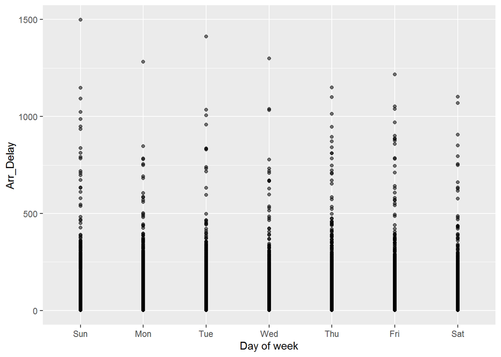

```r
flights_2018 %>%
  filter(Arr_Delay > 0) %>%
  ggplot(aes(x = as.factor(Date_Weekday), y = Arr_Delay, alpha = 0.1)) +
  geom_point() +
  xlab("Day of week") +
  theme(legend.position = "none")
```

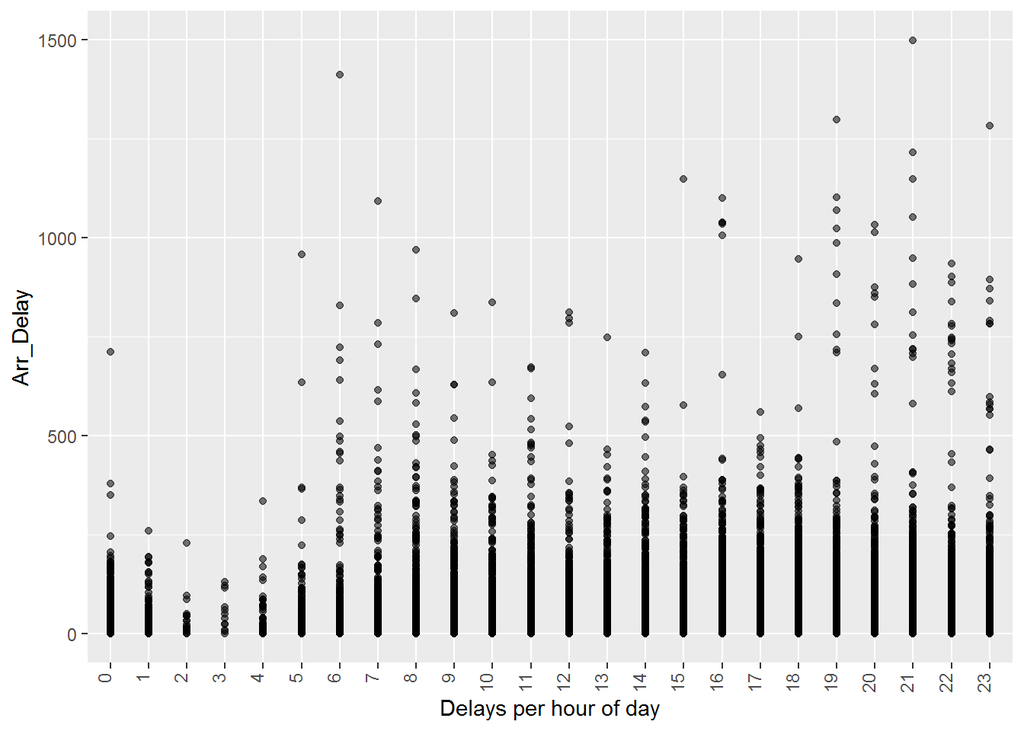

```r
flights_2018 %>%
  filter(Arr_Delay > 0) %>%
  ggplot(aes(x = as.factor(Arr_Time_Planned_Local_Hour),
             y = Arr_Delay, alpha = 0.1)) +
  geom_point() +
  xlab("Delays per hour of day") +
  theme(axis.text.x = element_text(angle = 90, hjust = 1, vjust = 0)) +
  theme(legend.position = "none")
```

```r
par(mfrow = c(2,2))
```

Air time per different time units

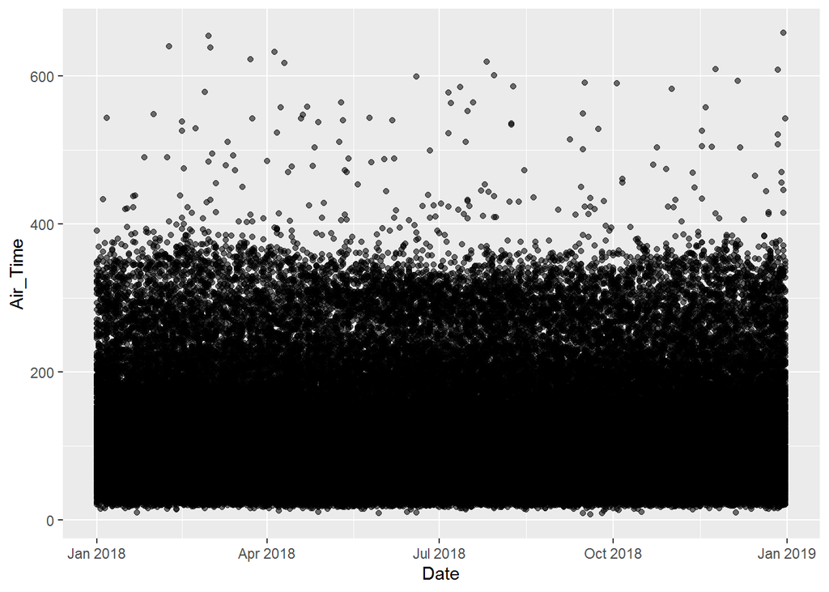

```r
flights_2018 %>%
  ggplot(aes(x = Date, y = Air_Time, alpha = 0.1)) +
  geom_point() +
  theme(legend.position = "none")
```

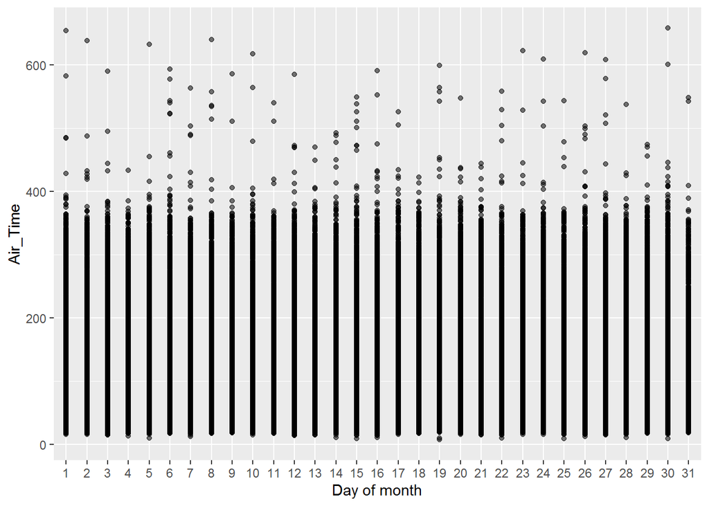

```r
flights_2018 %>%
  ggplot(aes(x = as.factor(Date_Day), y = Air_Time, alpha = 0.1)) +
  geom_point() +
  xlab("Day of month") +
  theme(legend.position = "none")
```

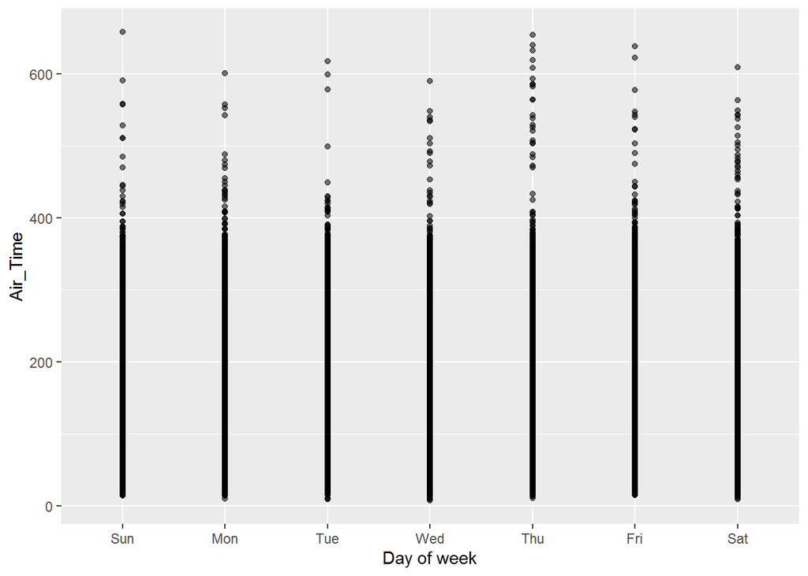

```r
flights_2018 %>%
  ggplot(aes(x = as.factor(Date_Weekday), y = Air_Time, alpha = 0.1)) +
  geom_point() +
  xlab("Day of week") +
  theme(legend.position = "none")
```

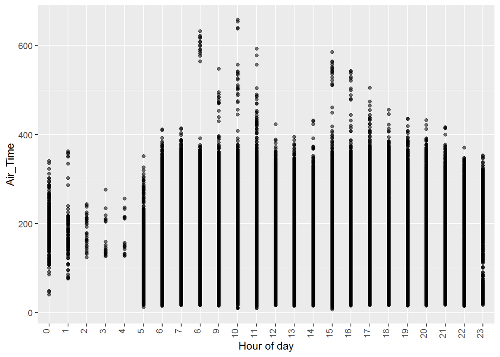

```r
flights_2018 %>%
  ggplot(aes(x = as.factor(Dep_Time_Planned_Local_Hour),
             y = Air_Time, alpha = 0.1)) +
  geom_point() +
  xlab("Hour of day") +
  theme(axis.text.x = element_text(angle = 90, hjust = 1, vjust = 0)) +
  theme(legend.position = "none")
```

```r
par(mfrow = c(2,2))
```

Distance per different time units

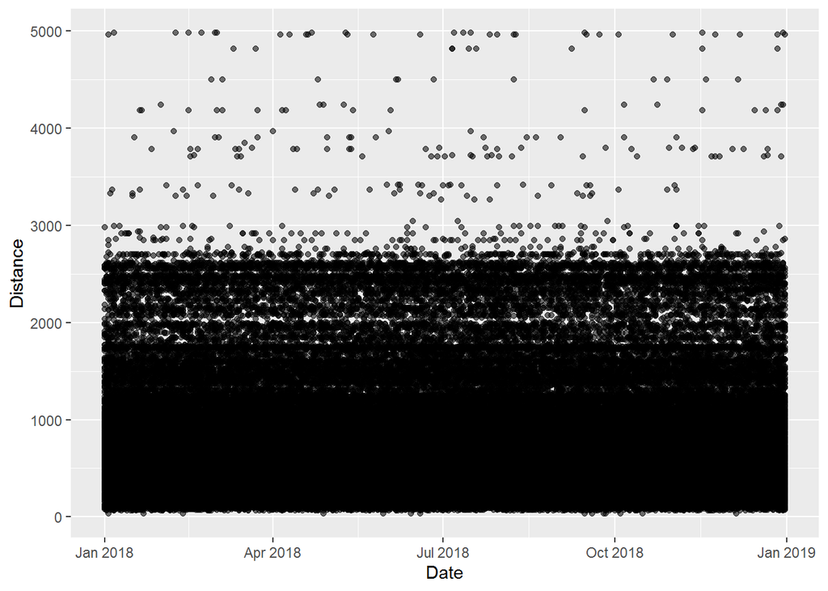

```r
flights_2018 %>%
  ggplot(aes(x = Date, y = Distance, alpha = 0.1)) +
  geom_point() +
  theme(legend.position = "none")
```

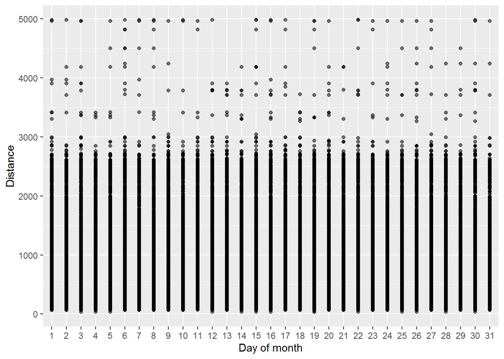

```r
flights_2018 %>%
  ggplot(aes(x = as.factor(Date_Day), y = Distance, alpha = 0.1)) +
  geom_point() +
  xlab("Day of month") +
  theme(legend.position = "none")
```

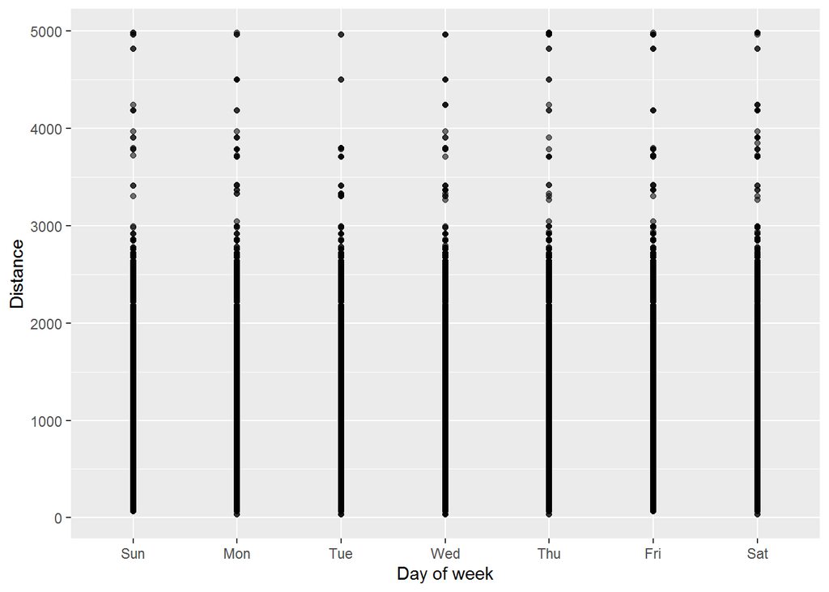

```r
flights_2018 %>%
  ggplot(aes(x = as.factor(Date_Weekday), y = Distance, alpha = 0.1)) +
  geom_point() +
  xlab("Day of week") +
  theme(legend.position = "none")
```

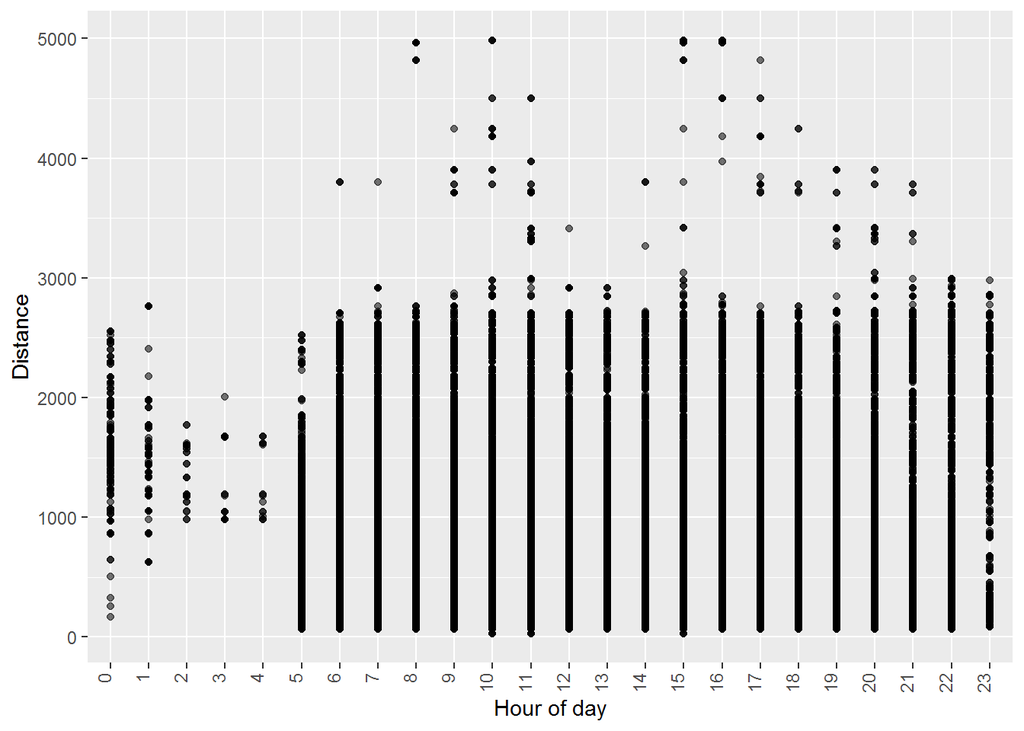

```r
flights_2018 %>%
  ggplot(aes(x = as.factor(Dep_Time_Planned_Local_Hour),
             y = Distance, alpha = 0.1)) +
  geom_point() +
  xlab("Hour of day") +
  theme(axis.text.x = element_text(angle = 90, hjust = 1, vjust = 0)) +
  theme(legend.position = "none")
```